# Project: No-show Appointments Analysis

- Introduction
- Data Wrangling
- Exploratory Data Analysis
- Conclusions

## Introduction

```python
import numpy as np
import pandas as pd
import matplotlib.pyplot as plt
import seaborn as sns
% matplotlib inline
```

## Data Wrangling

> In this section of the report, data is going to be cleaned to be ready for the analysis.

### General Properties

```python
df = pd.read_csv('noshowappointments_data.csv')
df.head()
```

|  | PatientId | AppointmentID | Gender | ScheduledDay | AppointmentDay | Age | Neighbourhood | Scholarship | Hipertension | Diabetes | Alcoholism | Handcap | SMS_received | No-show |
| --- | --- | --- | --- | --- | --- | --- | --- | --- | --- | --- | --- | --- | --- | --- |
| 0 | 2.987250e+13 | 5642903 | F | 2016-04-29T18:38:08Z | 2016-04-29T00:00:00Z | 62 | JARDIM DA PENHA | 0 | 1 | 0 | 0 | 0 | 0 | No |
| 1 | 5.589978e+14 | 5642503 | M | 2016-04-29T16:08:27Z | 2016-04-29T00:00:00Z | 56 | JARDIM DA PENHA | 0 | 0 | 0 | 0 | 0 | 0 | No |
| 2 | 4.262962e+12 | 5642549 | F | 2016-04-29T16:19:04Z | 2016-04-29T00:00:00Z | 62 | MATA DA PRAIA | 0 | 0 | 0 | 0 | 0 | 0 | No |
| 3 | 8.679512e+11 | 5642828 | F | 2016-04-29T17:29:31Z | 2016-04-29T00:00:00Z | 8 | PONTAL DE CAMBURI | 0 | 0 | 0 | 0 | 0 | 0 | No |
| 4 | 8.841186e+12 | 5642494 | F | 2016-04-29T16:07:23Z | 2016-04-29T00:00:00Z | 56 | JARDIM DA PENHA | 0 | 1 | 1 | 0 | 0 | 0 | No |

###### Define the number of the columns and rows in the whole dataset

```python
df.shape
```

```
(110527, 14)
```

###### Find the important statistical values to find infeasible values

```python
df.describe()
```

|  | PatientId | AppointmentID | Age | Scholarship | Hipertension | Diabetes | Alcoholism | Handcap | SMS_received |
| --- | --- | --- | --- | --- | --- | --- | --- | --- | --- |
| count | 1.105270e+05 | 1.105270e+05 | 110527.000000 | 110527.000000 | 110527.000000 | 110527.000000 | 110527.000000 | 110527.000000 | 110527.000000 |
| mean | 1.474963e+14 | 5.675305e+06 | 37.088874 | 0.098266 | 0.197246 | 0.071865 | 0.030400 | 0.022248 | 0.321026 |
| std | 2.560949e+14 | 7.129575e+04 | 23.110205 | 0.297675 | 0.397921 | 0.258265 | 0.171686 | 0.161543 | 0.466873 |
| min | 3.921784e+04 | 5.030230e+06 | -1.000000 | 0.000000 | 0.000000 | 0.000000 | 0.000000 | 0.000000 | 0.000000 |
| 25% | 4.172614e+12 | 5.640286e+06 | 18.000000 | 0.000000 | 0.000000 | 0.000000 | 0.000000 | 0.000000 | 0.000000 |
| 50% | 3.173184e+13 | 5.680573e+06 | 37.000000 | 0.000000 | 0.000000 | 0.000000 | 0.000000 | 0.000000 | 0.000000 |
| 75% | 9.439172e+13 | 5.725524e+06 | 55.000000 | 0.000000 | 0.000000 | 0.000000 | 0.000000 | 0.000000 | 1.000000 |
| max | 9.999816e+14 | 5.790484e+06 | 115.000000 | 1.000000 | 1.000000 | 1.000000 | 1.000000 | 4.000000 | 1.000000 |

###### Find missing values in each column

```python
df.info()
```

```
<class 'pandas.core.frame.DataFrame'>
RangeIndex: 110527 entries, 0 to 110526
Data columns (total 14 columns):
PatientId         110527 non-null float64
AppointmentID     110527 non-null int64
Gender            110527 non-null object
ScheduledDay      110527 non-null object
AppointmentDay    110527 non-null object
Age               110527 non-null int64
Neighbourhood     110527 non-null object
Scholarship       110527 non-null int64
Hipertension      110527 non-null int64
Diabetes          110527 non-null int64
Alcoholism        110527 non-null int64
Handcap           110527 non-null int64
SMS_received      110527 non-null int64
No-show           110527 non-null object
dtypes: float64(1), int64(8), object(5)
memory usage: 11.8+ MB
```

###### Drop the unimportant columns

```python
df.drop(['PatientId','AppointmentID','Neighbourhood'], axis=1, inplace=True)
```

###### Show the dataset after droping unimportant columns

```python
df.head()
```

|  | Gender | ScheduledDay | AppointmentDay | Age | Scholarship | Hipertension | Diabetes | Alcoholism | Handcap | SMS_received | No-show |
| --- | --- | --- | --- | --- | --- | --- | --- | --- | --- | --- | --- |
| 0 | F | 2016-04-29T18:38:08Z | 2016-04-29T00:00:00Z | 62 | 0 | 1 | 0 | 0 | 0 | 0 | No |
| 1 | M | 2016-04-29T16:08:27Z | 2016-04-29T00:00:00Z | 56 | 0 | 0 | 0 | 0 | 0 | 0 | No |
| 2 | F | 2016-04-29T16:19:04Z | 2016-04-29T00:00:00Z | 62 | 0 | 0 | 0 | 0 | 0 | 0 | No |
| 3 | F | 2016-04-29T17:29:31Z | 2016-04-29T00:00:00Z | 8 | 0 | 0 | 0 | 0 | 0 | 0 | No |
| 4 | F | 2016-04-29T16:07:23Z | 2016-04-29T00:00:00Z | 56 | 0 | 1 | 1 | 0 | 0 | 0 | No |

###### General view to visualize the dataset

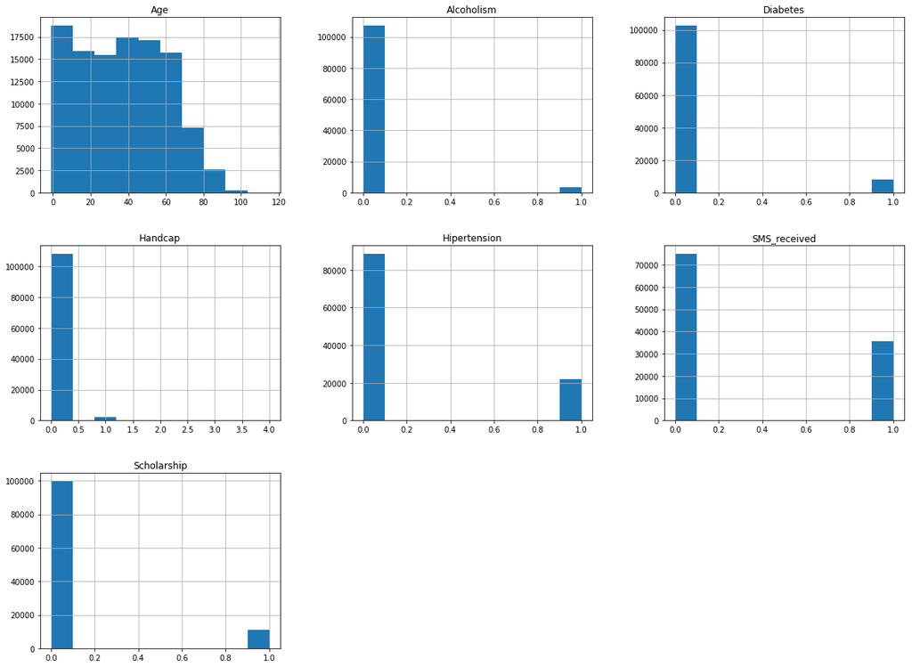

```python
df.hist(figsize=(20,15));
```

###### Find missing values in each column after dropping unimportant columns

```python
df.info()
```

```
<class 'pandas.core.frame.DataFrame'>
RangeIndex: 110527 entries, 0 to 110526
Data columns (total 11 columns):
Gender            110527 non-null object
ScheduledDay      110527 non-null object
AppointmentDay    110527 non-null object
Age               110527 non-null int64
Scholarship       110527 non-null int64
Hipertension      110527 non-null int64
Diabetes          110527 non-null int64
Alcoholism        110527 non-null int64
Handcap           110527 non-null int64
SMS_received      110527 non-null int64
No-show           110527 non-null object
dtypes: int64(7), object(4)
memory usage: 9.3+ MB
```

###### Drop the rows with any age value less than 0 since it is infeasible

```python
df = df[df.Age >= 0]
```

###### Show statistical values for each column to check for any infeasible values

```python
df.describe()
```

|  | Age | Scholarship | Hipertension | Diabetes | Alcoholism | Handcap | SMS_received |
| --- | --- | --- | --- | --- | --- | --- | --- |
| count | 110526.000000 | 110526.000000 | 110526.000000 | 110526.000000 | 110526.000000 | 110526.000000 | 110526.000000 |
| mean | 37.089219 | 0.098266 | 0.197248 | 0.071865 | 0.030400 | 0.022248 | 0.321029 |
| std | 23.110026 | 0.297676 | 0.397923 | 0.258266 | 0.171686 | 0.161543 | 0.466874 |
| min | 0.000000 | 0.000000 | 0.000000 | 0.000000 | 0.000000 | 0.000000 | 0.000000 |
| 25% | 18.000000 | 0.000000 | 0.000000 | 0.000000 | 0.000000 | 0.000000 | 0.000000 |
| 50% | 37.000000 | 0.000000 | 0.000000 | 0.000000 | 0.000000 | 0.000000 | 0.000000 |
| 75% | 55.000000 | 0.000000 | 0.000000 | 0.000000 | 0.000000 | 0.000000 | 1.000000 |
| max | 115.000000 | 1.000000 | 1.000000 | 1.000000 | 1.000000 | 4.000000 | 1.000000 |

###### Find missing values in each column after dropping infeasible rows with age value less than 0

```python
df.info()
```

```
<class 'pandas.core.frame.DataFrame'>
Int64Index: 110526 entries, 0 to 110526
Data columns (total 11 columns):
Gender            110526 non-null object
ScheduledDay      110526 non-null object
AppointmentDay    110526 non-null object
Age               110526 non-null int64
Scholarship       110526 non-null int64
Hipertension      110526 non-null int64
Diabetes          110526 non-null int64
Alcoholism        110526 non-null int64
Handcap           110526 non-null int64
SMS_received      110526 non-null int64
No-show           110526 non-null object
dtypes: int64(7), object(4)
memory usage: 10.1+ MB
```

###### Drop the rows with any handcap value greate than 1 since it is infeasible (either has a handcap or not)

```python
df = df[df.Handcap <= 1]
```

###### Show statistical values for each column to check for any more infeasible values

```python
df.describe()
```

|  | Age | Scholarship | Hipertension | Diabetes | Alcoholism | Handcap | SMS_received |
| --- | --- | --- | --- | --- | --- | --- | --- |
| count | 110327.000000 | 110327.000000 | 110327.000000 | 110327.000000 | 110327.000000 | 110327.000000 | 110327.000000 |
| mean | 37.070753 | 0.098281 | 0.196833 | 0.071605 | 0.030382 | 0.018509 | 0.321182 |
| std | 23.098052 | 0.297695 | 0.397607 | 0.257834 | 0.171638 | 0.134782 | 0.466932 |
| min | 0.000000 | 0.000000 | 0.000000 | 0.000000 | 0.000000 | 0.000000 | 0.000000 |
| 25% | 18.000000 | 0.000000 | 0.000000 | 0.000000 | 0.000000 | 0.000000 | 0.000000 |
| 50% | 37.000000 | 0.000000 | 0.000000 | 0.000000 | 0.000000 | 0.000000 | 0.000000 |
| 75% | 55.000000 | 0.000000 | 0.000000 | 0.000000 | 0.000000 | 0.000000 | 1.000000 |
| max | 115.000000 | 1.000000 | 1.000000 | 1.000000 | 1.000000 | 1.000000 | 1.000000 |

###### Replace patient not showing on the appointment columns from yes/no to true/false values to be easier to deal with (True means the patient did not show up on his/her appointment)

```python
df =df.replace({'No-show': {'Yes': True, 'No': False}})
df.head()
```

|  | Gender | ScheduledDay | AppointmentDay | Age | Scholarship | Hipertension | Diabetes | Alcoholism | Handcap | SMS_received | No-show |
| --- | --- | --- | --- | --- | --- | --- | --- | --- | --- | --- | --- |
| 0 | F | 2016-04-29T18:38:08Z | 2016-04-29T00:00:00Z | 62 | 0 | 1 | 0 | 0 | 0 | 0 | False |
| 1 | M | 2016-04-29T16:08:27Z | 2016-04-29T00:00:00Z | 56 | 0 | 0 | 0 | 0 | 0 | 0 | False |
| 2 | F | 2016-04-29T16:19:04Z | 2016-04-29T00:00:00Z | 62 | 0 | 0 | 0 | 0 | 0 | 0 | False |
| 3 | F | 2016-04-29T17:29:31Z | 2016-04-29T00:00:00Z | 8 | 0 | 0 | 0 | 0 | 0 | 0 | False |
| 4 | F | 2016-04-29T16:07:23Z | 2016-04-29T00:00:00Z | 56 | 0 | 1 | 1 | 0 | 0 | 0 | False |

###### Rename the 'No-show' column to 'No_show' to let the code be read correctly

```python
df.rename(columns={'No-show':'No_show'}, inplace=True)
df.head()
```

|  | Gender | ScheduledDay | AppointmentDay | Age | Scholarship | Hipertension | Diabetes | Alcoholism | Handcap | SMS_received | No_show |
| --- | --- | --- | --- | --- | --- | --- | --- | --- | --- | --- | --- |
| 0 | F | 2016-04-29T18:38:08Z | 2016-04-29T00:00:00Z | 62 | 0 | 1 | 0 | 0 | 0 | 0 | False |
| 1 | M | 2016-04-29T16:08:27Z | 2016-04-29T00:00:00Z | 56 | 0 | 0 | 0 | 0 | 0 | 0 | False |
| 2 | F | 2016-04-29T16:19:04Z | 2016-04-29T00:00:00Z | 62 | 0 | 0 | 0 | 0 | 0 | 0 | False |
| 3 | F | 2016-04-29T17:29:31Z | 2016-04-29T00:00:00Z | 8 | 0 | 0 | 0 | 0 | 0 | 0 | False |
| 4 | F | 2016-04-29T16:07:23Z | 2016-04-29T00:00:00Z | 56 | 0 | 1 | 1 | 0 | 0 | 0 | False |

###### Divide the appointments to two groups for those who apear on their appointment and those did not

```python
NotAppear = df.No_show == True
Appear = df.No_show == False
```

###### Final view to the data after cleanning it

```python
df.head()
```

|  | Gender | ScheduledDay | AppointmentDay | Age | Scholarship | Hipertension | Diabetes | Alcoholism | Handcap | SMS_received | No_show |
| --- | --- | --- | --- | --- | --- | --- | --- | --- | --- | --- | --- |
| 0 | F | 2016-04-29T18:38:08Z | 2016-04-29T00:00:00Z | 62 | 0 | 1 | 0 | 0 | 0 | 0 | False |
| 1 | M | 2016-04-29T16:08:27Z | 2016-04-29T00:00:00Z | 56 | 0 | 0 | 0 | 0 | 0 | 0 | False |
| 2 | F | 2016-04-29T16:19:04Z | 2016-04-29T00:00:00Z | 62 | 0 | 0 | 0 | 0 | 0 | 0 | False |
| 3 | F | 2016-04-29T17:29:31Z | 2016-04-29T00:00:00Z | 8 | 0 | 0 | 0 | 0 | 0 | 0 | False |
| 4 | F | 2016-04-29T16:07:23Z | 2016-04-29T00:00:00Z | 56 | 0 | 1 | 1 | 0 | 0 | 0 | False |

## Exploratory Data Analysis

### 1_ Does the gender affect the patients on attending their appointments?

###### Showing the total number of female and the total number of male on the data using bar plot and histogram plot (frequencies)

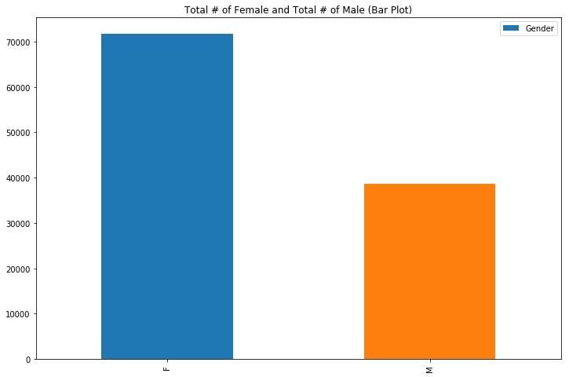

```python
df['Gender'].value_counts().plot.bar(figsize=(12,8));
plt.title('Total # of Female and Total # of Male (Bar Plot)')
plt.legend();
```

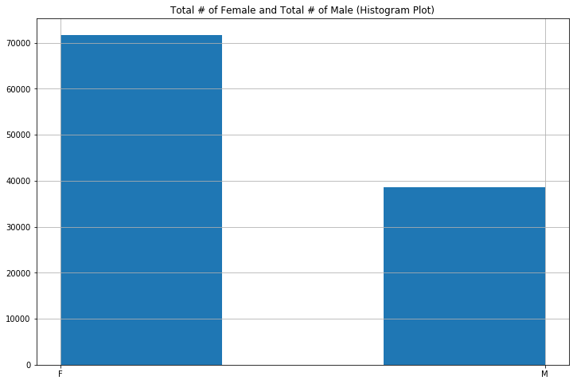

```python
df.Gender.hist(bins = 3, figsize=(12,8));
plt.title('Total # of Female and Total # of Male (Histogram Plot)')
plt.legend();
```

##### Show the # of patients appeared on their appointment and those did not based on the gender using histogram plot

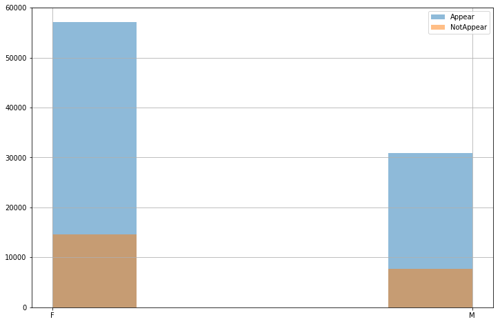

```python
df.Gender[Appear].hist(alpha = 0.5 , label = 'Appear', bins = 5, figsize=(12,8))
df.Gender[NotAppear].hist(alpha = 0.5 , label = 'NotAppear', bins = 5, figsize=(12,8))
plt.legend();
```

##### Show the # of patients appeared on their appointment and those did not for each gender using histogram plot

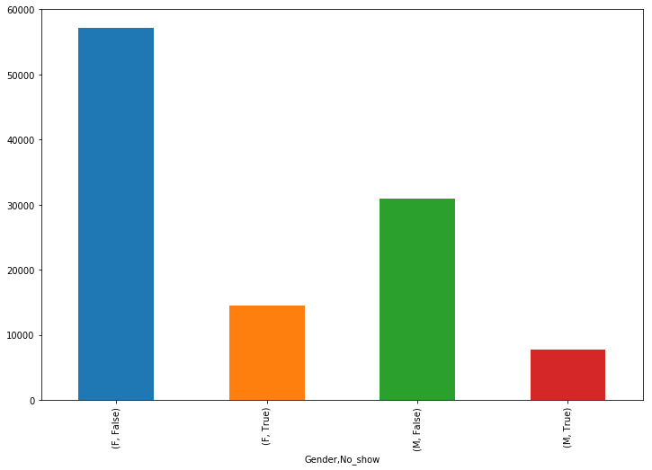

```python
df.groupby('Gender').No_show.value_counts().plot(kind='bar', figsize=(12,8));
```

### 2_ Does age affect patient attending their appointments?

###### Showing the total number of each age on the data using bar plot and histogram plot (frequencies)

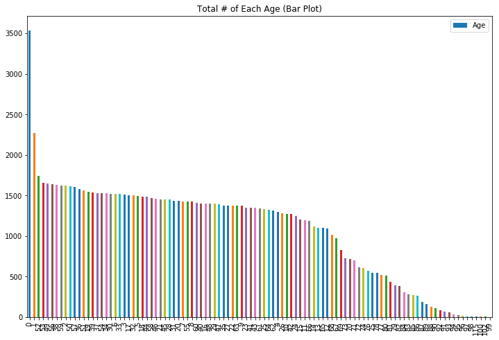

```python
df['Age'].value_counts().plot.bar(figsize=(12,8));
plt.title('Total # of Each Age (Bar Plot)')
plt.legend();
```

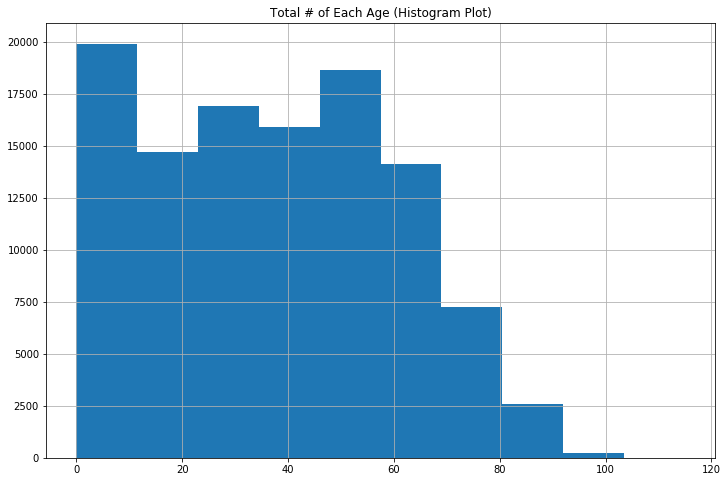

```python
df.Age.hist(figsize=(12,8));
plt.title('Total # of Each Age (Histogram Plot)')
plt.legend();
```

##### Show the # of patients appeared on their appointment and those did not based on the age of the patient using histogram plot

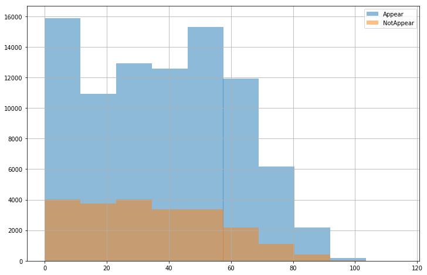

```python
df.Age[Appear].hist(alpha = 0.5 , label = 'Appear', figsize=(12,8))
df.Age[NotAppear].hist(alpha = 0.5 ,  label = 'NotAppear', figsize=(12,8))
plt.legend();
```

##### Show the # of patients appeared on their appointment and those did not for each age using histogram plot

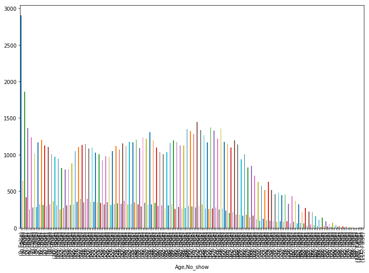

```python
df.groupby('Age').No_show.value_counts().plot(kind='bar', figsize=(12,8));
```

### 3_ Does the patient attendance depend on any disease?

###### Showing the total number of patints holding Hipertension and not holding on the data using bar plot and histogram plot (frequencies)

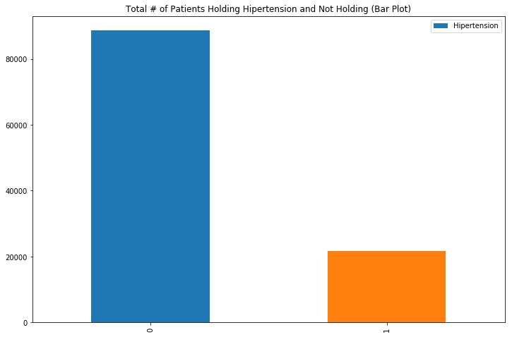

```python
df['Hipertension'].value_counts().plot.bar(figsize=(12,8));
plt.title('Total # of Patients Holding Hipertension and Not Holding (Bar Plot)')
plt.legend();
```

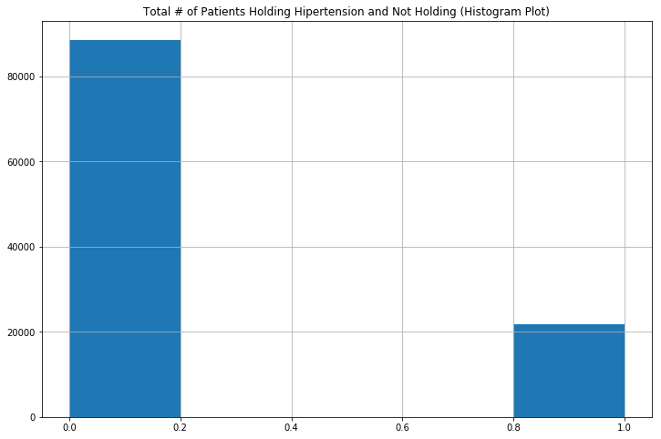

```python
df.Hipertension.hist(bins = 5, figsize=(12,8));
plt.title('Total # of Patients Holding Hipertension and Not Holding (Histogram Plot)')
plt.legend();
```

##### Show the # of patients appeared on their appointment and those did not based on holding Hipertension or not using histogram plot

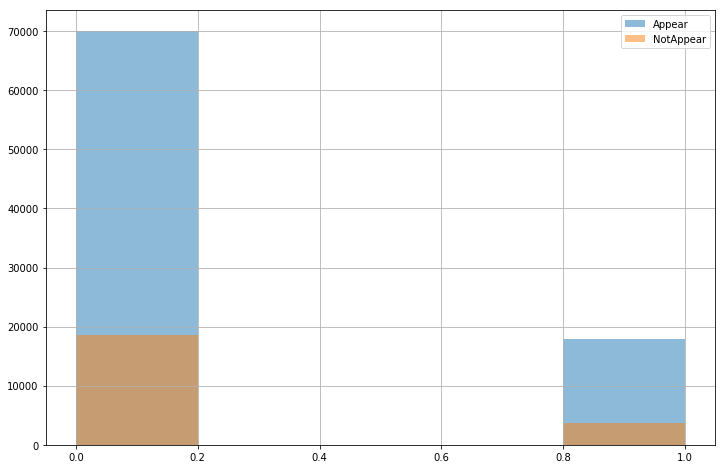

```python
df.Hipertension[Appear].hist(alpha = 0.5 , label = 'Appear', bins = 5, figsize=(12,8))
df.Hipertension[NotAppear].hist(alpha = 0.5 ,  label = 'NotAppear', bins = 5, figsize=(12,8))
plt.legend();
```

##### Show the # of patients appeared on their appointment and those did not once for holding and once for not holding Hipertension using histogram plot

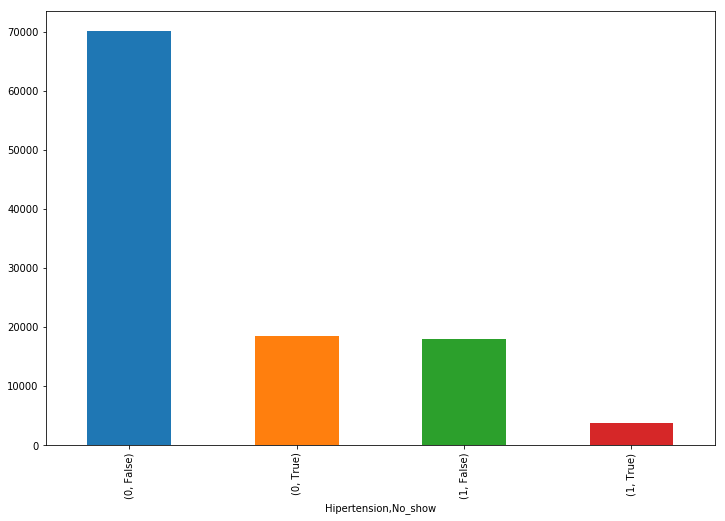

```python
df.groupby('Hipertension').No_show.value_counts().plot(kind='bar', figsize=(12,8));
```

###### Showing the total number of patints holding Diabetes and not holding on the data using bar plot and histogram plot (frequencies)

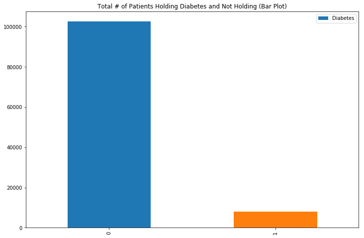

```python
df['Diabetes'].value_counts().plot.bar(figsize=(12,8));
plt.title('Total # of Patients Holding Diabetes and Not Holding (Bar Plot)')
plt.legend();
```

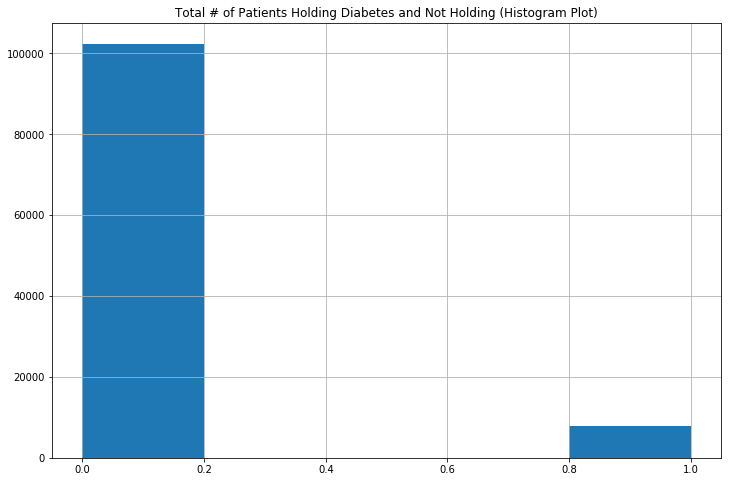

```python
df.Diabetes.hist(bins = 5, figsize=(12,8));
plt.title('Total # of Patients Holding Diabetes and Not Holding (Histogram Plot)')
plt.legend();
```

##### Show the # of patients appeared on their appointment and those did not based on holding Diabetes or not using histogram plot

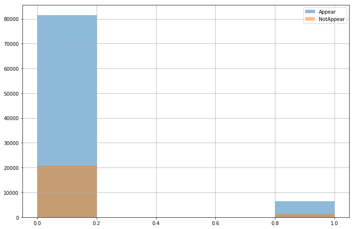

```python
df.Diabetes[Appear].hist(alpha = 0.5 , label = 'Appear', bins = 5, figsize=(12,8))
df.Diabetes[NotAppear].hist(alpha = 0.5 ,  label = 'NotAppear', bins = 5, figsize=(12,8))
plt.legend();
```

##### Show the # of patients appeared on their appointment and those did not once for holding and once for not holding Diabetes using histogram plot

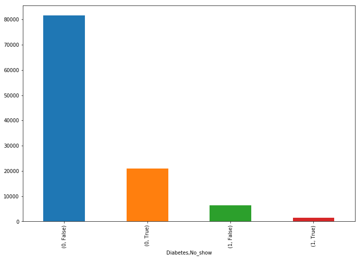

```python
df.groupby('Diabetes').No_show.value_counts().plot(kind='bar', figsize=(12,8));
```

###### Showing the total number of patints addicted to Alcohol and not on the data using bar plot and histogram plot (frequencies)

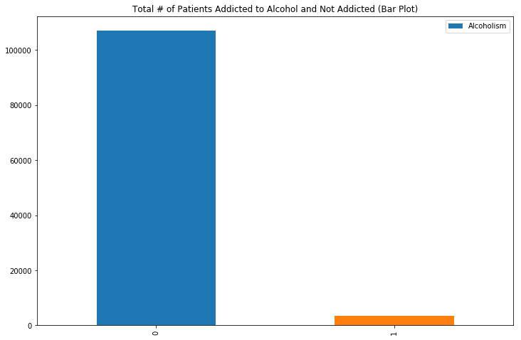

```python
df['Alcoholism'].value_counts().plot.bar(figsize=(12,8));
plt.title('Total # of Patients Addicted to Alcohol and Not Addicted (Bar Plot)')
plt.legend();
```

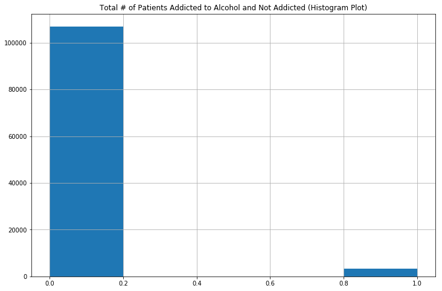

```python
df.Alcoholism.hist(bins = 5, figsize=(12,8));
plt.title('Total # of Patients Addicted to Alcohol and Not Addicted (Histogram Plot)')
plt.legend();
```

##### Show the # of patients appeared on their appointment and those did not based on addiction to Alcohol using histogram plot

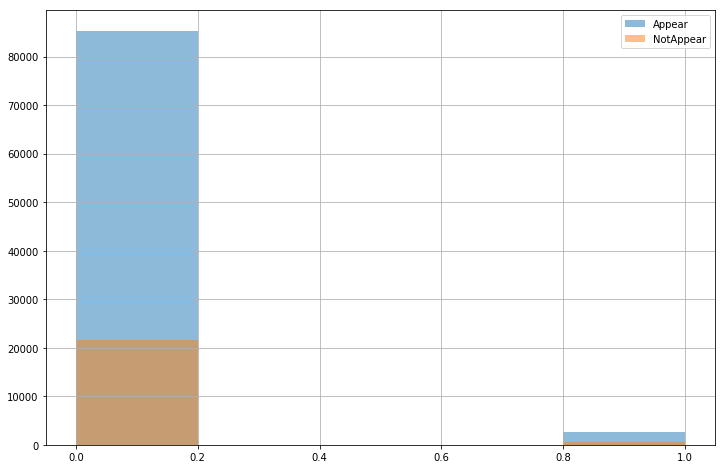

```python
df.Alcoholism[Appear].hist(alpha = 0.5 , label = 'Appear', bins = 5, figsize=(12,8))
df.Alcoholism[NotAppear].hist(alpha = 0.5 ,  label = 'NotAppear', bins = 5, figsize=(12,8))
plt.legend();
```

##### Show the # of patients appeared on their appointment and those did not once for addicted and once for not addicted to Alcohol using histogram plot

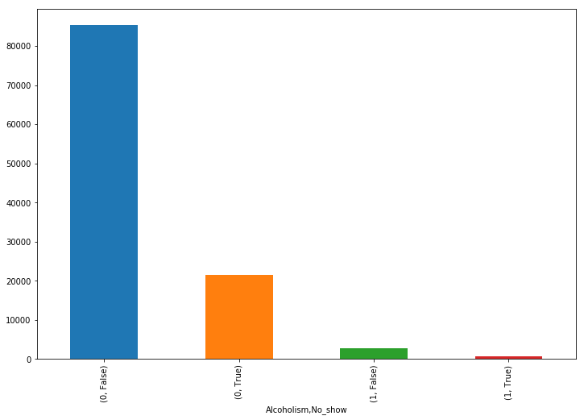

```python
df.groupby('Alcoholism').No_show.value_counts().plot(kind='bar', figsize=(12,8));
```

### 4_ Is the handcap a problem for the patient to attend his/her appointment?

###### Showing the total number of patients having handacap and not having on the data using bar plot and histogram plot (frequencies)

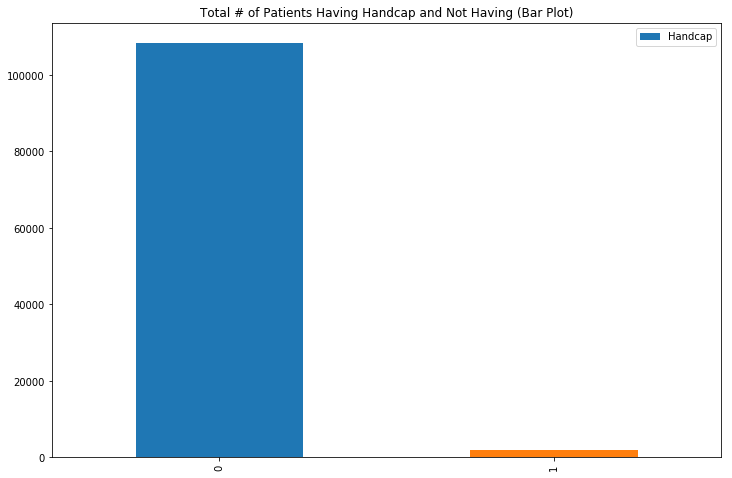

```python
df['Handcap'].value_counts().plot.bar(figsize=(12,8));
plt.title('Total # of Patients Having Handcap and Not Having (Bar Plot)')
plt.legend();
```

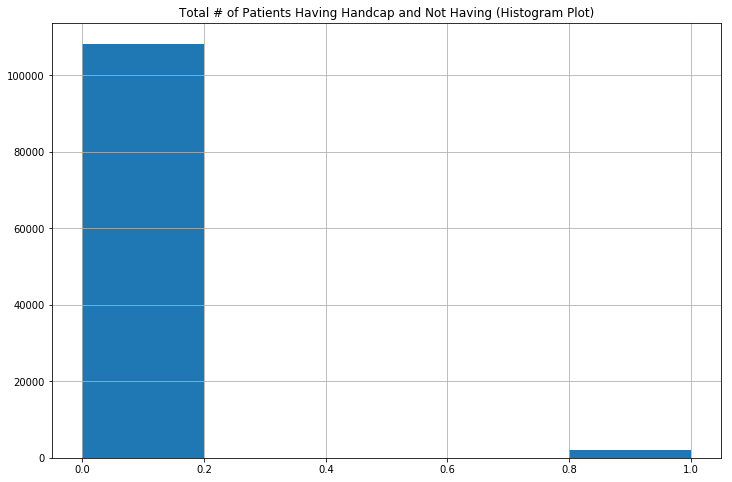

```python
df.Handcap.hist(bins = 5, figsize=(12,8));
plt.title('Total # of Patients Having Handcap and Not Having (Histogram Plot)')
plt.legend();
```

##### Show the # of patients appeared on their appointment and those did not based on having a handcap or not using histogram plot

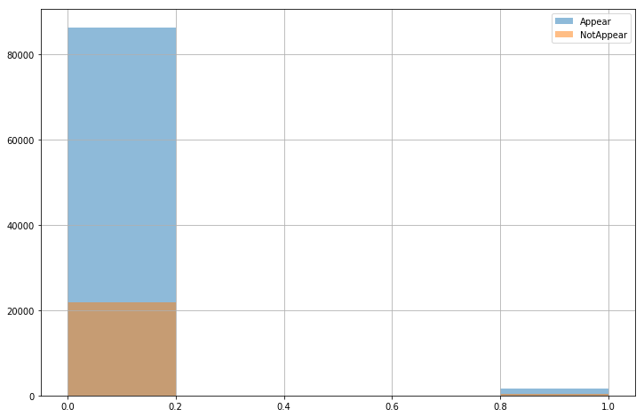

```python
df.Handcap[Appear].hist(alpha = 0.5 , label = 'Appear', bins = 5, figsize=(12,8))
df.Handcap[NotAppear].hist(alpha = 0.5 ,  label = 'NotAppear', bins = 5, figsize=(12,8))
plt.legend();
```

##### Show the # of patients appeared on their appointment and those did not once for having and once for not having a handcap using histogram plot

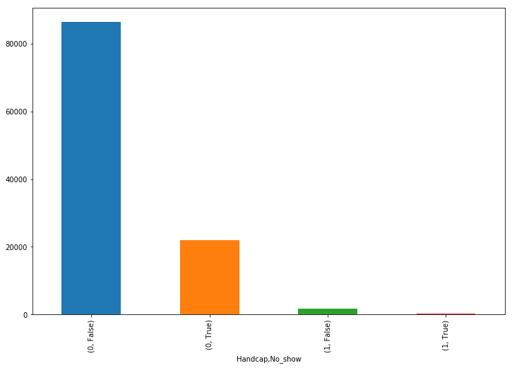

```python
df.groupby('Handcap').No_show.value_counts().plot(kind='bar', figsize=(12,8));
```

### 5_ Can receiving a sms message about the appointment details affect the patient attendance?

###### Showing the total number of patints received SMS messages and not receiving message on the data using bar plot and histogram plot (frequencies)

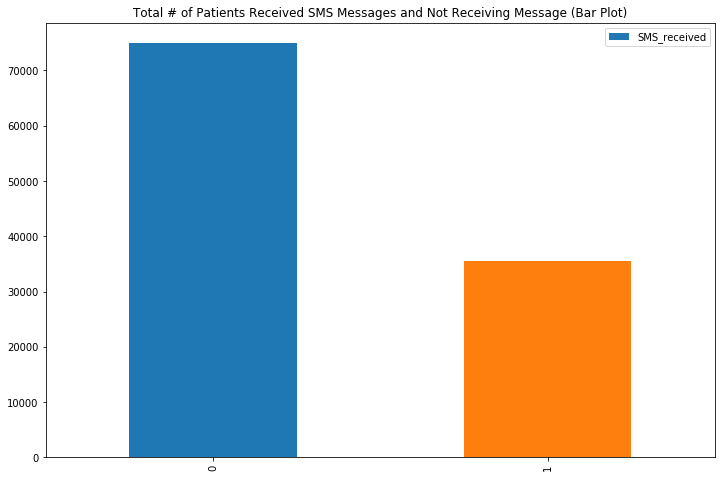

```python
df['SMS_received'].value_counts().plot.bar(figsize=(12,8));
plt.title('Total # of Patients Received SMS Messages and Not Receiving Message (Bar Plot)')
plt.legend();
```

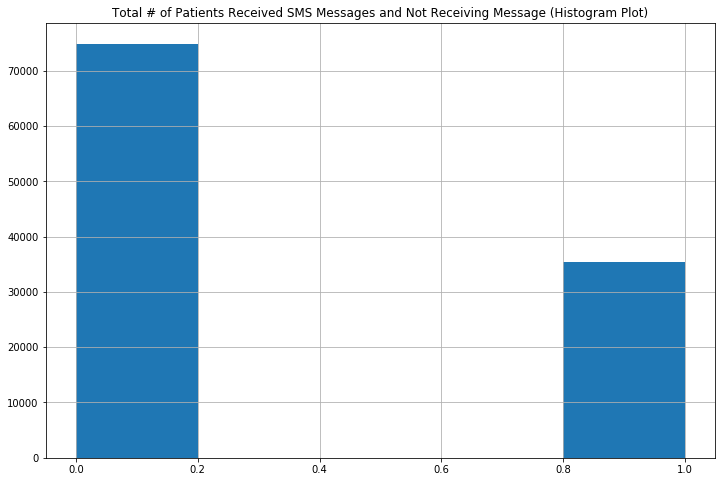

```python
df.SMS_received.hist(bins = 5, figsize=(12,8));
plt.title('Total # of Patients Received SMS Messages and Not Receiving Message (Histogram Plot)')
plt.legend();
```

##### Show the # of patients appeared on their appointment and those did not based on receiving a SMS message or not using histogram plot

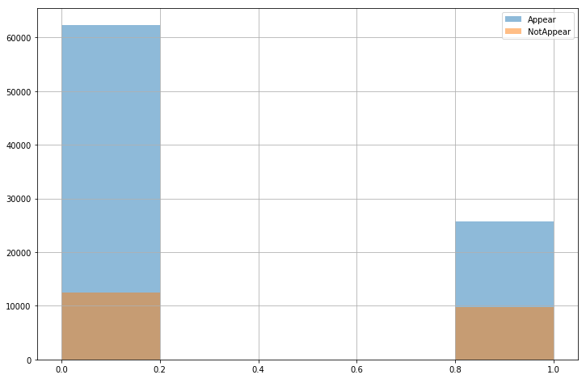

```python
df.SMS_received[Appear].hist(alpha = 0.5 , label = 'Appear' , bins = 5, figsize=(12,8))
df.SMS_received[NotAppear].hist(alpha = 0.5 ,  label = 'NotAppear', bins = 5, figsize=(12,8))
plt.legend();
```

##### Show the # of patients appeared on their appointment and those did not once for receiving and once for not receiving a SMS message using histogram plot

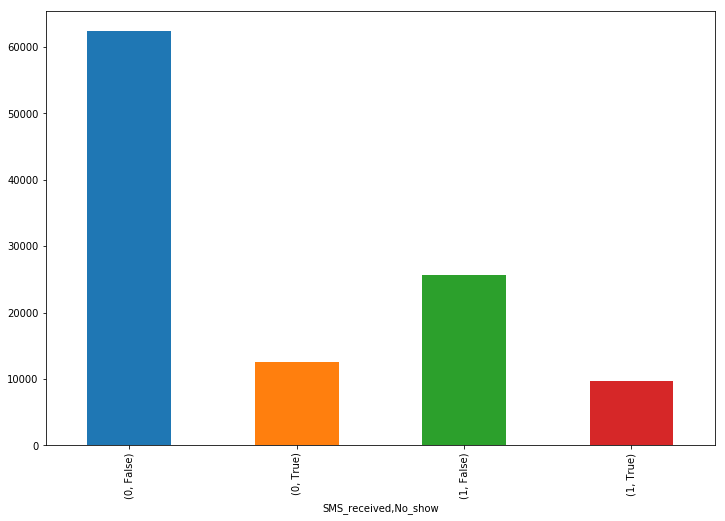

```python
df.groupby('SMS_received').No_show.value_counts().plot(kind='bar', figsize=(12,8));
```

### 6_ Does it affect the patient attendance if he/she has a scholarship?

###### Showing the total number of patints having a scholarship and not on the data using bar plot and histogram plot (frequencies)

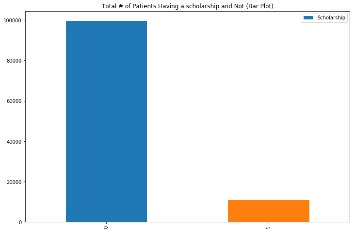

```python
df['Scholarship'].value_counts().plot.bar(figsize=(12,8));
plt.title('Total # of Patients Having a scholarship and Not (Bar Plot)')
plt.legend();
```

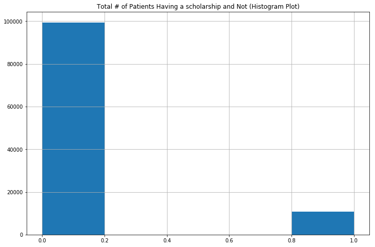

```python
df.Scholarship.hist(bins = 5, figsize=(12,8));
plt.title('Total # of Patients Having a scholarship and Not (Histogram Plot)')
plt.legend();
```

##### Show the # of patients appeared on their appointment and those did not based on having a scholarship or not using histogram plot

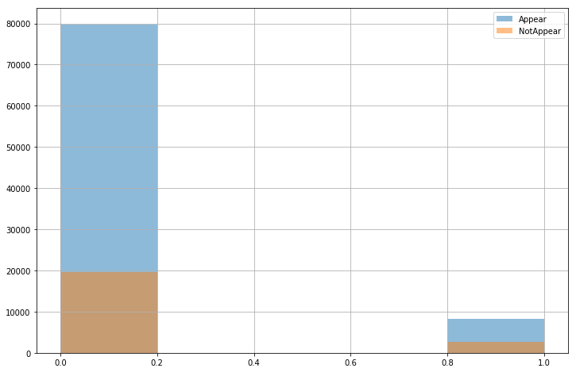

```python
df.Scholarship[Appear].hist(alpha = 0.5 , bins = 5 , label = 'Appear', figsize=(12,8))
df.Scholarship[NotAppear].hist(alpha = 0.5 , bins = 5 , label = 'NotAppear', figsize=(12,8))
plt.legend();
```

##### Show the # of patients appeared on their appointment and those did not once for having and once for not having a scholarship using histogram plot

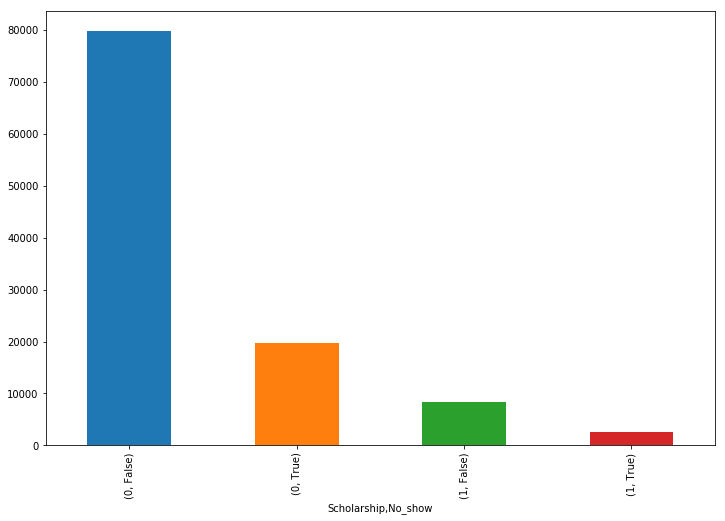

```python
df.groupby('Scholarship').No_show.value_counts().plot(kind='bar', figsize=(12,8));
```

## Conclusions

> Limitations: 1 *More details are required for more precise and accurate analysis. 2* Scheduled and appointment dates are not clear enough to be analyzed. 3 *Scholarship needs to be more specified by mentioning the level of scholarship. 4* Level of Hipertension, Diabetes, and Alcoholism need to be mentioned to have better analysis.

```python
from subprocess import call
call(['python', '-m', 'nbconvert', 'Investigate_a_Dataset.ipynb'])
```

```
0
```